# Risk Factor Analysis

## Outcome Variable

**Outcome Variable:** ever_swasted

## Predictor Variables

**Intervention Variable:** single

**Adjustment Set:**

- arm
- W_mage
- meducyrs
- feducyrs
- W_mhtcm
- W_mwtkg
- W_mbmi
- delta_W_mage
- delta_meducyrs
- delta_feducyrs
- delta_W_mhtcm
- delta_W_mwtkg
- delta_W_mbmi

## Stratifying Variables

The analysis was stratified on these variable(s):

- agecat
- studyid
- country

## Data Summary

| agecat | studyid | country | single | ever_swasted | n_cell | n |
| --- | --- | --- | --- | --- | --- | --- |
| 0-24 months | ki0047075b-MAL-ED | BANGLADESH | 0 | 0 | 242 | 263 |
| 0-24 months | ki0047075b-MAL-ED | BANGLADESH | 0 | 1 | 21 | 263 |
| 0-24 months | ki0047075b-MAL-ED | BANGLADESH | 1 | 0 | 0 | 263 |
| 0-24 months | ki0047075b-MAL-ED | BANGLADESH | 1 | 1 | 0 | 263 |
| 0-24 months | ki0047075b-MAL-ED | BRAZIL | 0 | 0 | 194 | 233 |
| 0-24 months | ki0047075b-MAL-ED | BRAZIL | 0 | 1 | 3 | 233 |
| 0-24 months | ki0047075b-MAL-ED | BRAZIL | 1 | 0 | 35 | 233 |
| 0-24 months | ki0047075b-MAL-ED | BRAZIL | 1 | 1 | 1 | 233 |
| 0-24 months | ki0047075b-MAL-ED | INDIA | 0 | 0 | 225 | 249 |
| 0-24 months | ki0047075b-MAL-ED | INDIA | 0 | 1 | 24 | 249 |
| 0-24 months | ki0047075b-MAL-ED | INDIA | 1 | 0 | 0 | 249 |
| 0-24 months | ki0047075b-MAL-ED | INDIA | 1 | 1 | 0 | 249 |
| 0-24 months | ki0047075b-MAL-ED | NEPAL | 0 | 0 | 231 | 240 |
| 0-24 months | ki0047075b-MAL-ED | NEPAL | 0 | 1 | 9 | 240 |
| 0-24 months | ki0047075b-MAL-ED | NEPAL | 1 | 0 | 0 | 240 |
| 0-24 months | ki0047075b-MAL-ED | NEPAL | 1 | 1 | 0 | 240 |
| 0-24 months | ki0047075b-MAL-ED | PERU | 0 | 0 | 265 | 302 |
| 0-24 months | ki0047075b-MAL-ED | PERU | 0 | 1 | 3 | 302 |
| 0-24 months | ki0047075b-MAL-ED | PERU | 1 | 0 | 34 | 302 |
| 0-24 months | ki0047075b-MAL-ED | PERU | 1 | 1 | 0 | 302 |
| 0-24 months | ki0047075b-MAL-ED | SOUTH AFRICA | 0 | 0 | 170 | 312 |
| 0-24 months | ki0047075b-MAL-ED | SOUTH AFRICA | 0 | 1 | 6 | 312 |
| 0-24 months | ki0047075b-MAL-ED | SOUTH AFRICA | 1 | 0 | 128 | 312 |
| 0-24 months | ki0047075b-MAL-ED | SOUTH AFRICA | 1 | 1 | 8 | 312 |
| 0-24 months | ki0047075b-MAL-ED | TANZANIA, UNITED REPUBLIC OF | 0 | 0 | 246 | 261 |
| 0-24 months | ki0047075b-MAL-ED | TANZANIA, UNITED REPUBLIC OF | 0 | 1 | 5 | 261 |
| 0-24 months | ki0047075b-MAL-ED | TANZANIA, UNITED REPUBLIC OF | 1 | 0 | 8 | 261 |
| 0-24 months | ki0047075b-MAL-ED | TANZANIA, UNITED REPUBLIC OF | 1 | 1 | 2 | 261 |
| 0-24 months | ki1066203-TanzaniaChild2 | TANZANIA, UNITED REPUBLIC OF | 0 | 0 | 2008 | 2375 |
| 0-24 months | ki1066203-TanzaniaChild2 | TANZANIA, UNITED REPUBLIC OF | 0 | 1 | 143 | 2375 |

[output cut: 138 more lines]

The following strata were considered:

- agecat: 0-24 months, studyid: ki0047075b-MAL-ED, country: BANGLADESH
- agecat: 0-24 months, studyid: ki0047075b-MAL-ED, country: BRAZIL
- agecat: 0-24 months, studyid: ki0047075b-MAL-ED, country: INDIA
- agecat: 0-24 months, studyid: ki0047075b-MAL-ED, country: NEPAL
- agecat: 0-24 months, studyid: ki0047075b-MAL-ED, country: PERU
- agecat: 0-24 months, studyid: ki0047075b-MAL-ED, country: SOUTH AFRICA
- agecat: 0-24 months, studyid: ki0047075b-MAL-ED, country: TANZANIA, UNITED REPUBLIC OF
- agecat: 0-24 months, studyid: ki1066203-TanzaniaChild2, country: TANZANIA, UNITED REPUBLIC OF
- agecat: 0-24 months, studyid: ki1112895-Guatemala BSC, country: GUATEMALA
- agecat: 0-24 months, studyid: ki1119695-PROBIT, country: BELARUS
- agecat: 0-24 months, studyid: ki1126311-ZVITAMBO, country: ZIMBABWE
- agecat: 0-24 months, studyid: ki1135781-COHORTS, country: GUATEMALA
- agecat: 0-24 months, studyid: ki1135781-COHORTS, country: INDIA
- agecat: 0-24 months, studyid: ki1135781-COHORTS, country: PHILIPPINES
- agecat: 0-6 months, studyid: ki0047075b-MAL-ED, country: BANGLADESH
- agecat: 0-6 months, studyid: ki0047075b-MAL-ED, country: BRAZIL
- agecat: 0-6 months, studyid: ki0047075b-MAL-ED, country: INDIA
- agecat: 0-6 months, studyid: ki0047075b-MAL-ED, country: NEPAL
- agecat: 0-6 months, studyid: ki0047075b-MAL-ED, country: PERU
- agecat: 0-6 months, studyid: ki0047075b-MAL-ED, country: SOUTH AFRICA
- agecat: 0-6 months, studyid: ki0047075b-MAL-ED, country: TANZANIA, UNITED REPUBLIC OF
- agecat: 0-6 months, studyid: ki1066203-TanzaniaChild2, country: TANZANIA, UNITED REPUBLIC OF
- agecat: 0-6 months, studyid: ki1112895-Guatemala BSC, country: GUATEMALA
- agecat: 0-6 months, studyid: ki1119695-PROBIT, country: BELARUS
- agecat: 0-6 months, studyid: ki1126311-ZVITAMBO, country: ZIMBABWE
- agecat: 0-6 months, studyid: ki1135781-COHORTS, country: GUATEMALA
- agecat: 0-6 months, studyid: ki1135781-COHORTS, country: INDIA
- agecat: 0-6 months, studyid: ki1135781-COHORTS, country: PHILIPPINES
- agecat: 6-24 months, studyid: ki0047075b-MAL-ED, country: BANGLADESH
- agecat: 6-24 months, studyid: ki0047075b-MAL-ED, country: BRAZIL
- agecat: 6-24 months, studyid: ki0047075b-MAL-ED, country: INDIA
- agecat: 6-24 months, studyid: ki0047075b-MAL-ED, country: NEPAL
- agecat: 6-24 months, studyid: ki0047075b-MAL-ED, country: PERU
- agecat: 6-24 months, studyid: ki0047075b-MAL-ED, country: SOUTH AFRICA
- agecat: 6-24 months, studyid: ki0047075b-MAL-ED, country: TANZANIA, UNITED REPUBLIC OF
- agecat: 6-24 months, studyid: ki1066203-TanzaniaChild2, country: TANZANIA, UNITED REPUBLIC OF
- agecat: 6-24 months, studyid: ki1112895-Guatemala BSC, country: GUATEMALA
- agecat: 6-24 months, studyid: ki1119695-PROBIT, country: BELARUS
- agecat: 6-24 months, studyid: ki1126311-ZVITAMBO, country: ZIMBABWE
- agecat: 6-24 months, studyid: ki1135781-COHORTS, country: GUATEMALA
- agecat: 6-24 months, studyid: ki1135781-COHORTS, country: INDIA
- agecat: 6-24 months, studyid: ki1135781-COHORTS, country: PHILIPPINES

### Dropped Strata

Some strata were dropped due to rare outcomes:

- agecat: 0-24 months, studyid: ki0047075b-MAL-ED, country: BANGLADESH
- agecat: 0-24 months, studyid: ki0047075b-MAL-ED, country: BRAZIL
- agecat: 0-24 months, studyid: ki0047075b-MAL-ED, country: INDIA
- agecat: 0-24 months, studyid: ki0047075b-MAL-ED, country: NEPAL
- agecat: 0-24 months, studyid: ki0047075b-MAL-ED, country: PERU
- agecat: 0-24 months, studyid: ki0047075b-MAL-ED, country: TANZANIA, UNITED REPUBLIC OF
- agecat: 0-24 months, studyid: ki1112895-Guatemala BSC, country: GUATEMALA
- agecat: 0-24 months, studyid: ki1135781-COHORTS, country: INDIA
- agecat: 0-6 months, studyid: ki0047075b-MAL-ED, country: BANGLADESH
- agecat: 0-6 months, studyid: ki0047075b-MAL-ED, country: BRAZIL
- agecat: 0-6 months, studyid: ki0047075b-MAL-ED, country: INDIA
- agecat: 0-6 months, studyid: ki0047075b-MAL-ED, country: NEPAL
- agecat: 0-6 months, studyid: ki0047075b-MAL-ED, country: PERU
- agecat: 0-6 months, studyid: ki0047075b-MAL-ED, country: SOUTH AFRICA
- agecat: 0-6 months, studyid: ki0047075b-MAL-ED, country: TANZANIA, UNITED REPUBLIC OF
- agecat: 0-6 months, studyid: ki1112895-Guatemala BSC, country: GUATEMALA
- agecat: 0-6 months, studyid: ki1135781-COHORTS, country: GUATEMALA
- agecat: 0-6 months, studyid: ki1135781-COHORTS, country: INDIA
- agecat: 6-24 months, studyid: ki0047075b-MAL-ED, country: BANGLADESH
- agecat: 6-24 months, studyid: ki0047075b-MAL-ED, country: BRAZIL
- agecat: 6-24 months, studyid: ki0047075b-MAL-ED, country: INDIA
- agecat: 6-24 months, studyid: ki0047075b-MAL-ED, country: NEPAL
- agecat: 6-24 months, studyid: ki0047075b-MAL-ED, country: PERU
- agecat: 6-24 months, studyid: ki0047075b-MAL-ED, country: SOUTH AFRICA
- agecat: 6-24 months, studyid: ki0047075b-MAL-ED, country: TANZANIA, UNITED REPUBLIC OF
- agecat: 6-24 months, studyid: ki1112895-Guatemala BSC, country: GUATEMALA
- agecat: 6-24 months, studyid: ki1119695-PROBIT, country: BELARUS
- agecat: 6-24 months, studyid: ki1135781-COHORTS, country: INDIA

## Methods Detail

We’re interested in the causal parameters $E[Y_a]$ for all values of $a \in \mathcal{A}$. These parameters represent the mean outcome if, possibly contrary to fact, we intervened to set all units to have $A=a$. Under the randomization and positivity assumptions, these are identified by the statistical parameters $\psi_a=E_W[E_{Y|A,W}(Y|A=a,W)]$. In addition, we’re interested in the mean of $Y$, $E[Y]$ under no intervention (the observed mean). We will estimate these parameters by using SuperLearner to fit the relevant likelihood factors – $E_{Y|A,W}(Y|A=a,W)$ and $p(A=a|W)$, and then updating our likelihood fit using a joint TMLE.

For unadjusted analyses ($W=\{\}$), initial likelihoods were estimated using Lrnr_glm to estimate the simple $E(Y|A)$ and Lrnr_mean to estimate $p(A)$. For adjusted analyses, a small library containing Lrnr_glmnet, Lrnr_xgboost, and Lrnr_mean was used.

Having estimated these parameters, we will then use the delta method to estimate relative risks and attributable risks relative to a prespecified baseline level of $A$.

# Results Detail

## Results Plots

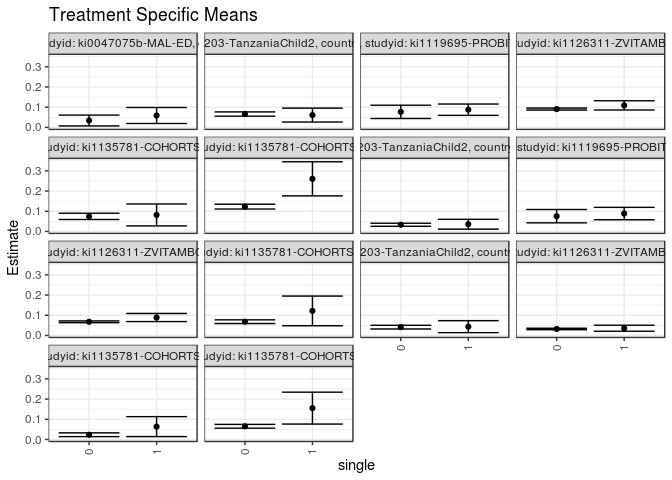

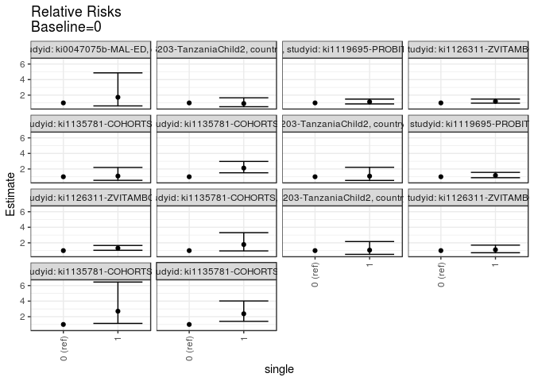

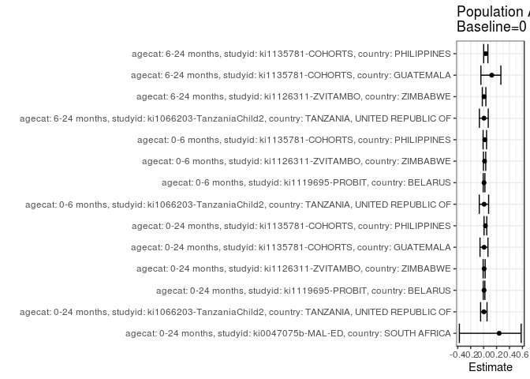

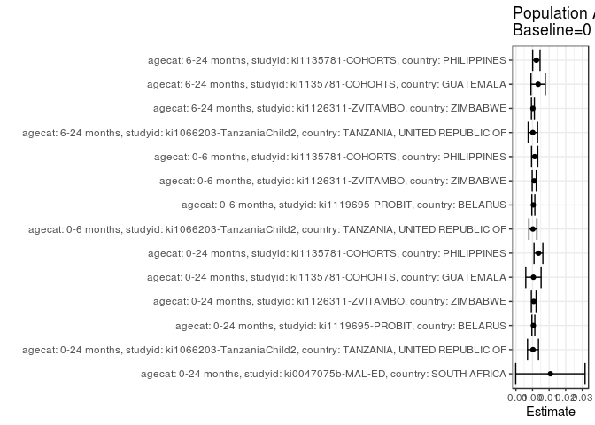

## Results Table

### Parameter: TSM

| agecat | studyid | country | intervention_level | baseline_level | estimate | ci_lower | ci_upper |
| --- | --- | --- | --- | --- | --- | --- | --- |
| 0-24 months | ki0047075b-MAL-ED | SOUTH AFRICA | 0 | NA | 0.0340909 | 0.0072389 | 0.0609429 |
| 0-24 months | ki0047075b-MAL-ED | SOUTH AFRICA | 1 | NA | 0.0588235 | 0.0192152 | 0.0984319 |
| 0-24 months | ki1066203-TanzaniaChild2 | TANZANIA, UNITED REPUBLIC OF | 0 | NA | 0.0662272 | 0.0556939 | 0.0767604 |
| 0-24 months | ki1066203-TanzaniaChild2 | TANZANIA, UNITED REPUBLIC OF | 1 | NA | 0.0609119 | 0.0264720 | 0.0953518 |
| 0-24 months | ki1119695-PROBIT | BELARUS | 0 | NA | 0.0769414 | 0.0441302 | 0.1097526 |
| 0-24 months | ki1119695-PROBIT | BELARUS | 1 | NA | 0.0875828 | 0.0595025 | 0.1156632 |
| 0-24 months | ki1126311-ZVITAMBO | ZIMBABWE | 0 | NA | 0.0907360 | 0.0857638 | 0.0957082 |
| 0-24 months | ki1126311-ZVITAMBO | ZIMBABWE | 1 | NA | 0.1090421 | 0.0863129 | 0.1317713 |
| 0-24 months | ki1135781-COHORTS | GUATEMALA | 0 | NA | 0.0746133 | 0.0590715 | 0.0901551 |
| 0-24 months | ki1135781-COHORTS | GUATEMALA | 1 | NA | 0.0816327 | 0.0274005 | 0.1358648 |
| 0-24 months | ki1135781-COHORTS | PHILIPPINES | 0 | NA | 0.1228665 | 0.1108971 | 0.1348359 |
| 0-24 months | ki1135781-COHORTS | PHILIPPINES | 1 | NA | 0.2604322 | 0.1760051 | 0.3448592 |
| 0-6 months | ki1066203-TanzaniaChild2 | TANZANIA, UNITED REPUBLIC OF | 0 | NA | 0.0330079 | 0.0254563 | 0.0405595 |
| 0-6 months | ki1066203-TanzaniaChild2 | TANZANIA, UNITED REPUBLIC OF | 1 | NA | 0.0357143 | 0.0114068 | 0.0600217 |
| 0-6 months | ki1119695-PROBIT | BELARUS | 0 | NA | 0.0755413 | 0.0426186 | 0.1084639 |
| 0-6 months | ki1119695-PROBIT | BELARUS | 1 | NA | 0.0885865 | 0.0579629 | 0.1192102 |
| 0-6 months | ki1126311-ZVITAMBO | ZIMBABWE | 0 | NA | 0.0676317 | 0.0632934 | 0.0719700 |
| 0-6 months | ki1126311-ZVITAMBO | ZIMBABWE | 1 | NA | 0.0889371 | 0.0689314 | 0.1089427 |
| 0-6 months | ki1135781-COHORTS | PHILIPPINES | 0 | NA | 0.0682594 | 0.0591229 | 0.0773959 |
| 0-6 months | ki1135781-COHORTS | PHILIPPINES | 1 | NA | 0.1216216 | 0.0482307 | 0.1950126 |
| 6-24 months | ki1066203-TanzaniaChild2 | TANZANIA, UNITED REPUBLIC OF | 0 | NA | 0.0412088 | 0.0320744 | 0.0503431 |
| 6-24 months | ki1066203-TanzaniaChild2 | TANZANIA, UNITED REPUBLIC OF | 1 | NA | 0.0437158 | 0.0140850 | 0.0733467 |
| 6-24 months | ki1126311-ZVITAMBO | ZIMBABWE | 0 | NA | 0.0322410 | 0.0287759 | 0.0357061 |
| 6-24 months | ki1126311-ZVITAMBO | ZIMBABWE | 1 | NA | 0.0358800 | 0.0210485 | 0.0507115 |
| 6-24 months | ki1135781-COHORTS | GUATEMALA | 0 | NA | 0.0235988 | 0.0142654 | 0.0329323 |
| 6-24 months | ki1135781-COHORTS | GUATEMALA | 1 | NA | 0.0638298 | 0.0143909 | 0.1132687 |
| 6-24 months | ki1135781-COHORTS | PHILIPPINES | 0 | NA | 0.0654167 | 0.0560617 | 0.0747717 |
| 6-24 months | ki1135781-COHORTS | PHILIPPINES | 1 | NA | 0.1553579 | 0.0764597 | 0.2342562 |

### Parameter: E(Y)

| agecat | studyid | country | intervention_level | baseline_level | estimate | ci_lower | ci_upper |
| --- | --- | --- | --- | --- | --- | --- | --- |
| 0-24 months | ki0047075b-MAL-ED | SOUTH AFRICA | NA | NA | 0.0448718 | 0.0218634 | 0.0678801 |
| 0-24 months | ki1066203-TanzaniaChild2 | TANZANIA, UNITED REPUBLIC OF | NA | NA | 0.0665263 | 0.0565020 | 0.0765506 |
| 0-24 months | ki1119695-PROBIT | BELARUS | NA | NA | 0.0774648 | 0.0450418 | 0.1098878 |
| 0-24 months | ki1126311-ZVITAMBO | ZIMBABWE | NA | NA | 0.0914788 | 0.0866831 | 0.0962745 |
| 0-24 months | ki1135781-COHORTS | GUATEMALA | NA | NA | 0.0751880 | 0.0602434 | 0.0901325 |
| 0-24 months | ki1135781-COHORTS | PHILIPPINES | NA | NA | 0.1264559 | 0.1145706 | 0.1383412 |
| 0-6 months | ki1066203-TanzaniaChild2 | TANZANIA, UNITED REPUBLIC OF | NA | NA | 0.0332632 | 0.0260497 | 0.0404766 |
| 0-6 months | ki1119695-PROBIT | BELARUS | NA | NA | 0.0760580 | 0.0435003 | 0.1086157 |
| 0-6 months | ki1126311-ZVITAMBO | ZIMBABWE | NA | NA | 0.0686680 | 0.0644472 | 0.0728888 |
| 0-6 months | ki1135781-COHORTS | PHILIPPINES | NA | NA | 0.0695739 | 0.0604740 | 0.0786738 |
| 6-24 months | ki1066203-TanzaniaChild2 | TANZANIA, UNITED REPUBLIC OF | NA | NA | 0.0414378 | 0.0327076 | 0.0501681 |
| 6-24 months | ki1126311-ZVITAMBO | ZIMBABWE | NA | NA | 0.0324883 | 0.0291209 | 0.0358556 |
| 6-24 months | ki1135781-COHORTS | GUATEMALA | NA | NA | 0.0270027 | 0.0174671 | 0.0365383 |
| 6-24 months | ki1135781-COHORTS | PHILIPPINES | NA | NA | 0.0677477 | 0.0583957 | 0.0770998 |

### Parameter: RR

| agecat | studyid | country | intervention_level | baseline_level | estimate | ci_lower | ci_upper |
| --- | --- | --- | --- | --- | --- | --- | --- |
| 0-24 months | ki0047075b-MAL-ED | SOUTH AFRICA | 0 | 0 | 1.0000000 | 1.0000000 | 1.000000 |
| 0-24 months | ki0047075b-MAL-ED | SOUTH AFRICA | 1 | 0 | 1.7254902 | 0.6121797 | 4.863468 |
| 0-24 months | ki1066203-TanzaniaChild2 | TANZANIA, UNITED REPUBLIC OF | 0 | 0 | 1.0000000 | 1.0000000 | 1.000000 |
| 0-24 months | ki1066203-TanzaniaChild2 | TANZANIA, UNITED REPUBLIC OF | 1 | 0 | 0.9197417 | 0.5111349 | 1.654994 |
| 0-24 months | ki1119695-PROBIT | BELARUS | 0 | 0 | 1.0000000 | 1.0000000 | 1.000000 |
| 0-24 months | ki1119695-PROBIT | BELARUS | 1 | 0 | 1.1383057 | 0.8701227 | 1.489146 |
| 0-24 months | ki1126311-ZVITAMBO | ZIMBABWE | 0 | 0 | 1.0000000 | 1.0000000 | 1.000000 |
| 0-24 months | ki1126311-ZVITAMBO | ZIMBABWE | 1 | 0 | 1.2017509 | 0.9688269 | 1.490674 |
| 0-24 months | ki1135781-COHORTS | GUATEMALA | 0 | 0 | 1.0000000 | 1.0000000 | 1.000000 |
| 0-24 months | ki1135781-COHORTS | GUATEMALA | 1 | 0 | 1.0940767 | 0.5453529 | 2.194916 |
| 0-24 months | ki1135781-COHORTS | PHILIPPINES | 0 | 0 | 1.0000000 | 1.0000000 | 1.000000 |
| 0-24 months | ki1135781-COHORTS | PHILIPPINES | 1 | 0 | 2.1196351 | 1.5109289 | 2.973570 |
| 0-6 months | ki1066203-TanzaniaChild2 | TANZANIA, UNITED REPUBLIC OF | 0 | 0 | 1.0000000 | 1.0000000 | 1.000000 |
| 0-6 months | ki1066203-TanzaniaChild2 | TANZANIA, UNITED REPUBLIC OF | 1 | 0 | 1.0819920 | 0.5276998 | 2.218509 |
| 0-6 months | ki1119695-PROBIT | BELARUS | 0 | 0 | 1.0000000 | 1.0000000 | 1.000000 |
| 0-6 months | ki1119695-PROBIT | BELARUS | 1 | 0 | 1.1726906 | 0.8804021 | 1.562017 |
| 0-6 months | ki1126311-ZVITAMBO | ZIMBABWE | 0 | 0 | 1.0000000 | 1.0000000 | 1.000000 |
| 0-6 months | ki1126311-ZVITAMBO | ZIMBABWE | 1 | 0 | 1.3150206 | 1.0407445 | 1.661579 |
| 0-6 months | ki1135781-COHORTS | PHILIPPINES | 0 | 0 | 1.0000000 | 1.0000000 | 1.000000 |
| 0-6 months | ki1135781-COHORTS | PHILIPPINES | 1 | 0 | 1.7817568 | 0.9603060 | 3.305881 |
| 6-24 months | ki1066203-TanzaniaChild2 | TANZANIA, UNITED REPUBLIC OF | 0 | 0 | 1.0000000 | 1.0000000 | 1.000000 |
| 6-24 months | ki1066203-TanzaniaChild2 | TANZANIA, UNITED REPUBLIC OF | 1 | 0 | 1.0608379 | 0.5199252 | 2.164498 |
| 6-24 months | ki1126311-ZVITAMBO | ZIMBABWE | 0 | 0 | 1.0000000 | 1.0000000 | 1.000000 |
| 6-24 months | ki1126311-ZVITAMBO | ZIMBABWE | 1 | 0 | 1.1128676 | 0.7260107 | 1.705862 |
| 6-24 months | ki1135781-COHORTS | GUATEMALA | 0 | 0 | 1.0000000 | 1.0000000 | 1.000000 |
| 6-24 months | ki1135781-COHORTS | GUATEMALA | 1 | 0 | 2.7047872 | 1.1335391 | 6.454011 |
| 6-24 months | ki1135781-COHORTS | PHILIPPINES | 0 | 0 | 1.0000000 | 1.0000000 | 1.000000 |
| 6-24 months | ki1135781-COHORTS | PHILIPPINES | 1 | 0 | 2.3748978 | 1.4018920 | 4.023234 |

### Parameter: PAR

| agecat | studyid | country | intervention_level | baseline_level | estimate | ci_lower | ci_upper |
| --- | --- | --- | --- | --- | --- | --- | --- |
| 0-24 months | ki0047075b-MAL-ED | SOUTH AFRICA | 0 | NA | 0.0107809 | -0.0101223 | 0.0316841 |
| 0-24 months | ki1066203-TanzaniaChild2 | TANZANIA, UNITED REPUBLIC OF | 0 | NA | 0.0002991 | -0.0029952 | 0.0035935 |
| 0-24 months | ki1119695-PROBIT | BELARUS | 0 | NA | 0.0005234 | -0.0003615 | 0.0014083 |
| 0-24 months | ki1126311-ZVITAMBO | ZIMBABWE | 0 | NA | 0.0007428 | -0.0006861 | 0.0021717 |
| 0-24 months | ki1135781-COHORTS | GUATEMALA | 0 | NA | 0.0005747 | -0.0040454 | 0.0051948 |
| 0-24 months | ki1135781-COHORTS | PHILIPPINES | 0 | NA | 0.0035894 | 0.0009352 | 0.0062436 |
| 0-6 months | ki1066203-TanzaniaChild2 | TANZANIA, UNITED REPUBLIC OF | 0 | NA | 0.0002553 | -0.0021456 | 0.0026561 |
| 0-6 months | ki1119695-PROBIT | BELARUS | 0 | NA | 0.0005168 | -0.0003898 | 0.0014234 |
| 0-6 months | ki1126311-ZVITAMBO | ZIMBABWE | 0 | NA | 0.0010363 | -0.0001864 | 0.0022590 |
| 0-6 months | ki1135781-COHORTS | PHILIPPINES | 0 | NA | 0.0013145 | -0.0005579 | 0.0031870 |
| 6-24 months | ki1066203-TanzaniaChild2 | TANZANIA, UNITED REPUBLIC OF | 0 | NA | 0.0002291 | -0.0026040 | 0.0030621 |
| 6-24 months | ki1126311-ZVITAMBO | ZIMBABWE | 0 | NA | 0.0002472 | -0.0006486 | 0.0011431 |
| 6-24 months | ki1135781-COHORTS | GUATEMALA | 0 | NA | 0.0034039 | -0.0009036 | 0.0077114 |
| 6-24 months | ki1135781-COHORTS | PHILIPPINES | 0 | NA | 0.0023311 | 0.0001130 | 0.0045492 |

### Parameter: PAF

| agecat | studyid | country | intervention_level | baseline_level | estimate | ci_lower | ci_upper |
| --- | --- | --- | --- | --- | --- | --- | --- |
| 0-24 months | ki0047075b-MAL-ED | SOUTH AFRICA | 0 | NA | 0.2402597 | -0.3745652 | 0.5800816 |
| 0-24 months | ki1066203-TanzaniaChild2 | TANZANIA, UNITED REPUBLIC OF | 0 | NA | 0.0044964 | -0.0462756 | 0.0528047 |
| 0-24 months | ki1119695-PROBIT | BELARUS | 0 | NA | 0.0067564 | -0.0062163 | 0.0195619 |
| 0-24 months | ki1126311-ZVITAMBO | ZIMBABWE | 0 | NA | 0.0081198 | -0.0076198 | 0.0236135 |
| 0-24 months | ki1135781-COHORTS | GUATEMALA | 0 | NA | 0.0076433 | -0.0557292 | 0.0672117 |
| 0-24 months | ki1135781-COHORTS | PHILIPPINES | 0 | NA | 0.0283846 | 0.0072120 | 0.0491056 |
| 0-6 months | ki1066203-TanzaniaChild2 | TANZANIA, UNITED REPUBLIC OF | 0 | NA | 0.0076738 | -0.0671750 | 0.0772729 |
| 0-6 months | ki1119695-PROBIT | BELARUS | 0 | NA | 0.0067942 | -0.0066238 | 0.0200333 |
| 0-6 months | ki1126311-ZVITAMBO | ZIMBABWE | 0 | NA | 0.0150913 | -0.0028564 | 0.0327177 |
| 0-6 months | ki1135781-COHORTS | PHILIPPINES | 0 | NA | 0.0188938 | -0.0082968 | 0.0453512 |
| 6-24 months | ki1066203-TanzaniaChild2 | TANZANIA, UNITED REPUBLIC OF | 0 | NA | 0.0055276 | -0.0652363 | 0.0715907 |
| 6-24 months | ki1126311-ZVITAMBO | ZIMBABWE | 0 | NA | 0.0076104 | -0.0203456 | 0.0348004 |
| 6-24 months | ki1135781-COHORTS | GUATEMALA | 0 | NA | 0.1260570 | -0.0417454 | 0.2668302 |
| 6-24 months | ki1135781-COHORTS | PHILIPPINES | 0 | NA | 0.0344080 | 0.0013264 | 0.0663937 |